# Plot types

In ggplot, the `geom_xxx()` funciton defines the type of plot that is drawn. in the example below, we use `geom_point()`, which makes dots.

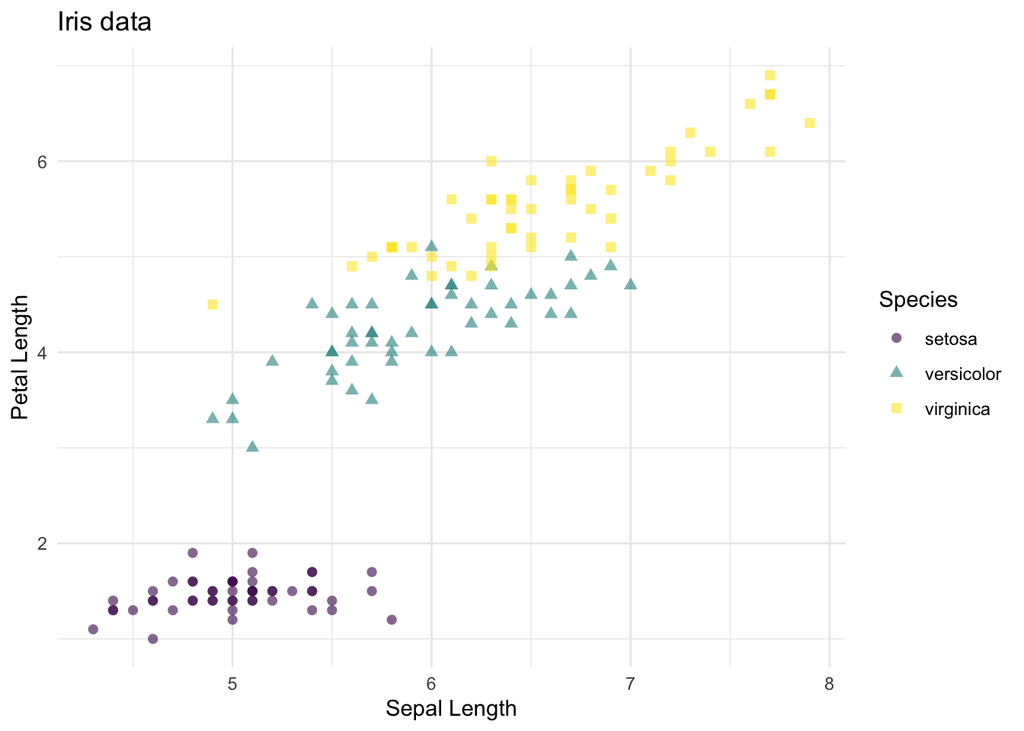

## Continous variables

Continous data is often visualized using dots, boxplots or bars. A heat map can also be used.

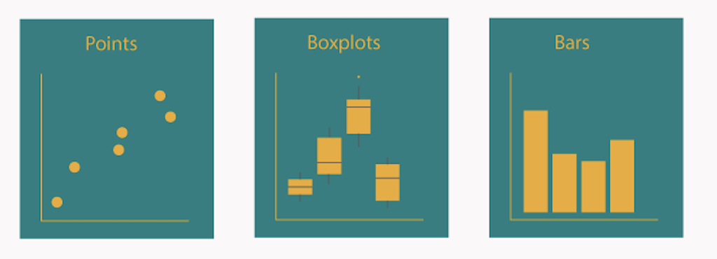

## Code

### Points

Here is the code to make a dotplot using `geom_point()`:

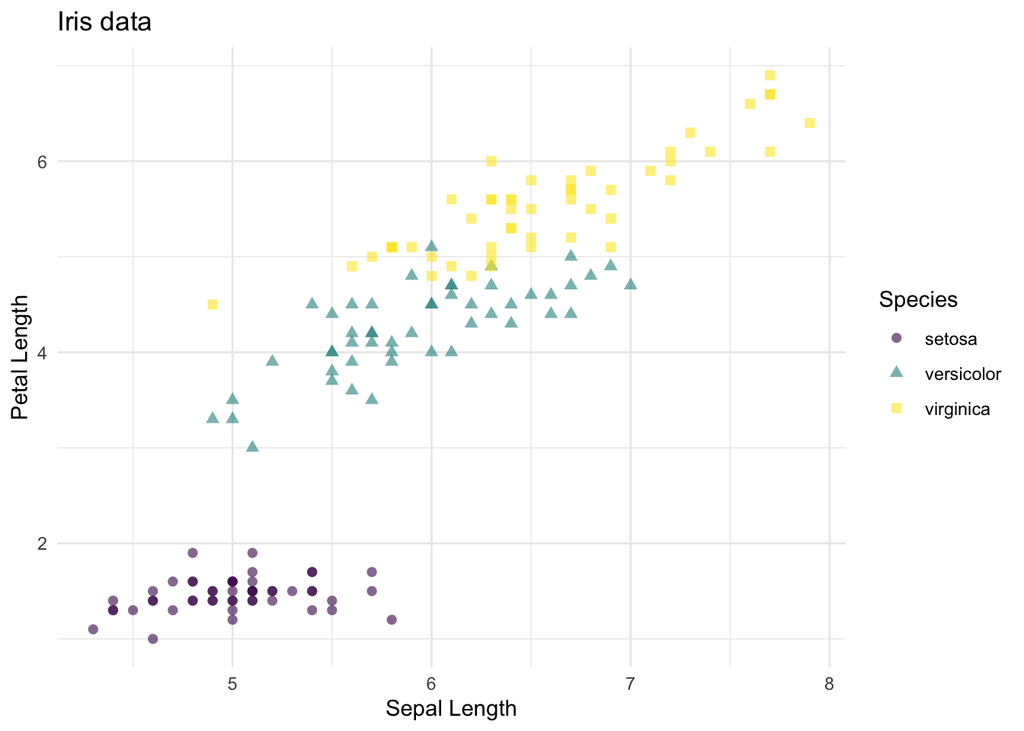

```r
ggplot(data = iris, aes(x = Sepal.Length, y = Petal.Length, colour = Species, shape = Species)) +
  geom_point(size = 2, alpha = 0.6) +
  labs(title = "Iris data", x = "Sepal Length", y = "Petal Length") +
  scale_color_viridis_d() +
  theme_minimal()
```

### Box

Here is the code to make a boxplot using `geom_boxplot()`:

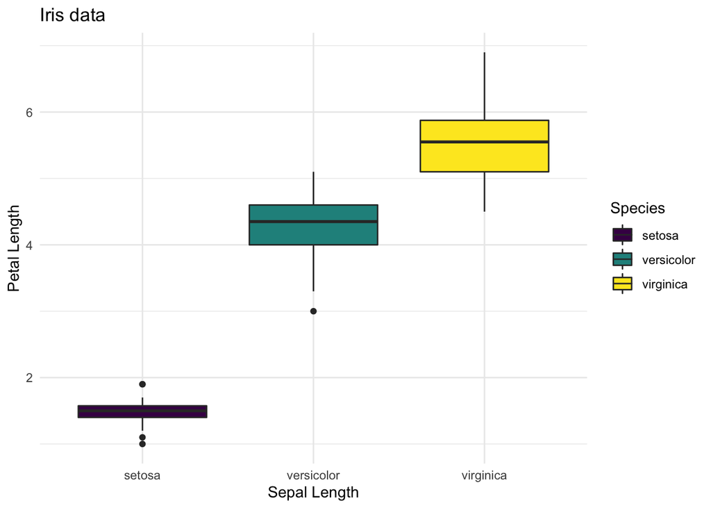

```r
ggplot(data = iris, aes(x = Species, y = Petal.Length, fill = Species)) +
  geom_boxplot() +
  labs(title = "Iris data", x = "Sepal Length", y = "Petal Length") +
  scale_fill_viridis_d() +
  theme_minimal()
```

### Bars

Here is the code to make a barplot using `geom_bar()`:

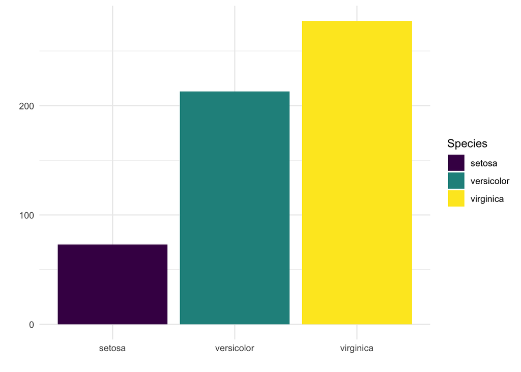

```r
ggplot(data = iris, aes(y = Petal.Length, x = Species, fill = Species)) +
  geom_bar(stat = "identity") +
  labs(x = "", y = "") +
  scale_fill_viridis_d() +
  theme_minimal()
```

## Categorical data, factors and groups

To show categorical data, factors and groups we often use boxplots, or other elements. We can use colour, size, shape or linetype to distinguish different groups. Another option is to divide the plot into subplots using the facet function.

[figure not shown]

## Distributions

Histograms and density plots are most commonly used to plot densities. To visualize several density at the same time, boxplots, violin and sina plot are useful.

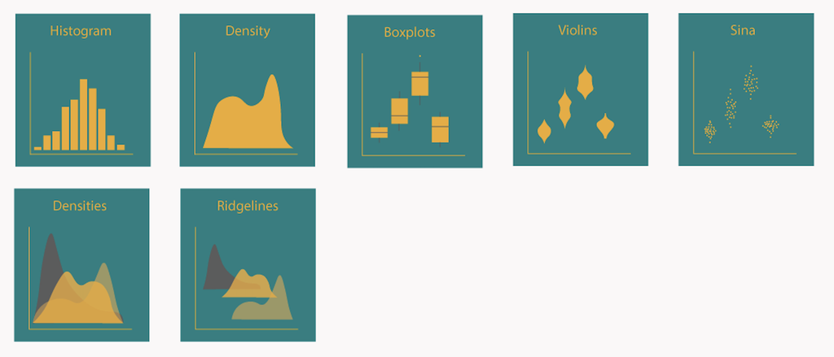

## Proportions

Proportions are often displayed using barplots or stacked barplots.

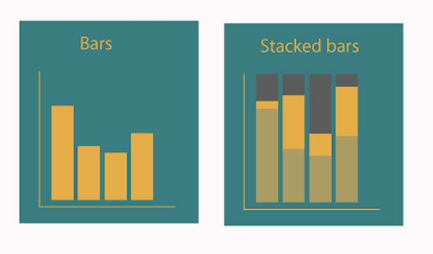

## x~y relationships

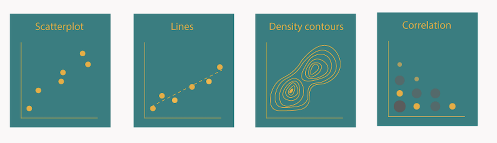

## Spatial and temporal data

Spatial data is often shown on maps. Temporal data, is often shown with lines/smooth

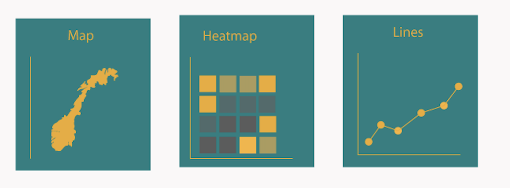

## Uncertainty

Errorbars are often used to show uncertainty of the data or likely values - posterior distribbution/eye plot - confidence bands

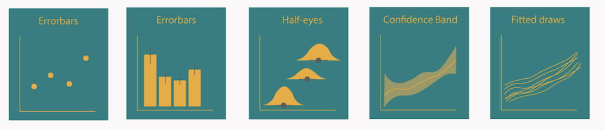